# Experimental design

## Experimental Design

An experiment is a set of observations made under conditions controlled by the observer.

- If the conditions are controlled we can reliably draw conclusions about cause and effect.
- Observational data (surveys) can be used to identify associations but not causal relationships.

## Experimental Design

Experiments are used to answer questions about a processes.

- How do controllable inputs (treatment factors/independent variable) impact outcomes of interest (responses/dependent variable)?
- Experiments involve varying the inputs and assessing the effect on the outputs.
- The way the experiment is designed determines which questions can be answered.

## Experimental Design

[R. A. Fisher](https://en.wikipedia.org/wiki/Ronald_Fisher) identified three important principles that should be considered when designing an experiment.

[figure not shown]

- Randomisation
- Relpication
- Blocking

## Randomization

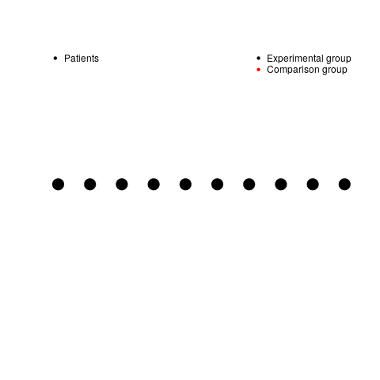

## Randomization

[figure not shown]

Image from [Wild About Statistics](https://youtu.be/bi-LNLrFYcQ)

## Randomization

[figure not shown]

## Randomization

Allocation of experimental units to combinations of treatment factor levels should be determined by a random process.

[figure not shown]

## Randomization

- Participants assigned by chance
- Ensures a "Fair test"
- Reduce bias
- prevents selection bias
- insures against accidental bias

## Randomization

- Ensures that each treatment has the same probability of getting good (or bad) units and thus avoids systematic bias.
- Independence
- Typically statistical analysis assumes that observations are independent. This is almost never strictly true in practice but randomisation means that our estimates will behave as if they were based on independent observations.

## Replication

## Replication

Replication means that each treatment is used more than once in the experiment.

- For true replication the entire process must be repeated separately each time.

## Replication

We can estimate the inherent variability in the data from the replicate observations. This allows us to judge whether an observed difference could be due to chance variation.

## Blocking

## Blocking

Experimental units are divided into subsets (called blocks) so that units within the same block are more similar than units from different subsets or blocks.

## Blocking

If two units in the same block get different treatments the treatments can be compared more precisely than if the treatments were assigned to units in different blocks.

- Blocking allows us to increase our ability to detect differences without increasing the size of the experiment.

## Assessed lab work

- Choose a topic of interest and identify a question of interest you have related to that topic. Write a few sentences outlining the scientific question you with to answer and any hypotheses you may have.
- Note the independent and dependent variables in your scenario.
- Design an experiment that could help you test the hypothesis/answer the question your question of interest. Write a few short paragraphs outlining the experimental design outlining how Fisher’s three principles of experimental design have played a part.

## Assessed lab work

As part of this lab you are also expected to peer review 4 of your classmate’s worksheets. Although this will be an anonymous process, from the view of the lab, be aware that your feedback will be returned to your peers. When carrying out your peer review please follow the rubric given fairly and carefully (the review rubric will be circulated after the assignment’s due date)

- Be kind
- Ask for clarification if something is unclear on the feedback form
- Point out strengths as well as weaknesses
- Be sure that your comments are clear and specific
- Be careful not to let your own opinions bias your review

https://b.socrative.com/login/student/ Room Name: BIOSCI220